# Class 14 Mini-project COVID-19 Vaccination Rates

Xihan Zhou (PID: A15845684)

2022-03-03

## Getting Started

```r
vax <- read.csv("covid19vaccinesbyzipcode_test.csv")
head(vax)
```

|  | as_of_date | zip_code_tabulation_area | local_health_jurisdiction | county | vaccine_equity_metric_quartile | vem_source | age12_plus_population | age5_plus_population | persons_fully_vaccinated | persons_partially_vaccinated | percent_of_population_fully_vaccinated | percent_of_population_partially_vaccinated | percent_of_population_with_1_plus_dose | booster_recip_count | redacted |
| --- | --- | --- | --- | --- | --- | --- | --- | --- | --- | --- | --- | --- | --- | --- | --- |
| 1 | 2021-01-05 | 92549 | Riverside | Riverside | 3 | Healthy Places Index Score | 2348.4 | 2461 | NA | NA | NA | NA | NA | NA | Information redacted in accordance with CA state privacy requirements |
| 2 | 2021-01-05 | 92130 | San Diego | San Diego | 4 | Healthy Places Index Score | 46300.3 | 53102 | 61 | 27 | 0.001149 | 0.000508 | 0.001657 | NA | Information redacted in accordance with CA state privacy requirements |
| 3 | 2021-01-05 | 92397 | San Bernardino | San Bernardino | 3 | Healthy Places Index Score | 3695.6 | 4225 | NA | NA | NA | NA | NA | NA | Information redacted in accordance with CA state privacy requirements |
| 4 | 2021-01-05 | 94563 | Contra Costa | Contra Costa | 4 | Healthy Places Index Score | 17216.1 | 18896 | NA | NA | NA | NA | NA | NA | Information redacted in accordance with CA state privacy requirements |
| 5 | 2021-01-05 | 94519 | Contra Costa | Contra Costa | 3 | Healthy Places Index Score | 16861.2 | 18678 | NA | NA | NA | NA | NA | NA | Information redacted in accordance with CA state privacy requirements |
| 6 | 2021-01-05 | 91042 | Los Angeles | Los Angeles | 2 | Healthy Places Index Score | 23962.2 | 25741 | NA | NA | NA | NA | NA | NA | Information redacted in accordance with CA state privacy requirements |

# Q1. What column details the total number of people fully vaccinated?

persons_fully_vaccinated

# Q2. What column details the Zip code tabulation area?

zip_code_tabulation_area

# Q3. What is the earliest date in this dataset?

```r
vax$as_of_date[1]
```

```
## [1] "2021-01-05"
```

# Q4. What is the latest date in this dataset?

```r
vax$as_of_date[nrow(vax)]
```

```
## [1] "2022-03-01"
```

```r
skimr::skim(vax)
```

Data summary

| Name | vax |
| --- | --- |
| Number of rows | 107604 |
| Number of columns | 15 |
| _______________________ |  |
| Column type frequency: |  |
| character | 5 |
| numeric | 10 |
| ________________________ |  |
| Group variables | None |

**Variable type: character**

| skim_variable | n_missing | complete_rate | min | max | empty | n_unique | whitespace |
| --- | --- | --- | --- | --- | --- | --- | --- |
| as_of_date | 0 | 1 | 10 | 10 | 0 | 61 | 0 |
| local_health_jurisdiction | 0 | 1 | 0 | 15 | 305 | 62 | 0 |
| county | 0 | 1 | 0 | 15 | 305 | 59 | 0 |
| vem_source | 0 | 1 | 15 | 26 | 0 | 3 | 0 |
| redacted | 0 | 1 | 2 | 69 | 0 | 2 | 0 |

**Variable type: numeric**

| skim_variable | n_missing | complete_rate | mean | sd | p0 | p25 | p50 | p75 | p100 | hist |
| --- | --- | --- | --- | --- | --- | --- | --- | --- | --- | --- |
| zip_code_tabulation_area | 0 | 1.00 | 93665.11 | 1817.39 | 90001 | 92257.75 | 93658.50 | 95380.50 | 97635.0 | ▃▅▅▇▁ |
| vaccine_equity_metric_quartile | 5307 | 0.95 | 2.44 | 1.11 | 1 | 1.00 | 2.00 | 3.00 | 4.0 | ▇▇▁▇▇ |
| age12_plus_population | 0 | 1.00 | 18895.04 | 18993.91 | 0 | 1346.95 | 13685.10 | 31756.12 | 88556.7 | ▇▃▂▁▁ |
| age5_plus_population | 0 | 1.00 | 20875.24 | 21106.02 | 0 | 1460.50 | 15364.00 | 34877.00 | 101902.0 | ▇▃▂▁▁ |
| persons_fully_vaccinated | 18338 | 0.83 | 12155.61 | 13063.88 | 11 | 1066.25 | 7374.50 | 20005.00 | 77744.0 | ▇▃▁▁▁ |
| persons_partially_vaccinated | 18338 | 0.83 | 831.74 | 1348.68 | 11 | 76.00 | 372.00 | 1076.00 | 34219.0 | ▇▁▁▁▁ |
| percent_of_population_fully_vaccinated | 18338 | 0.83 | 0.51 | 0.26 | 0 | 0.33 | 0.54 | 0.70 | 1.0 | ▅▅▇▇▃ |
| percent_of_population_partially_vaccinated | 18338 | 0.83 | 0.05 | 0.09 | 0 | 0.01 | 0.03 | 0.05 | 1.0 | ▇▁▁▁▁ |
| percent_of_population_with_1_plus_dose | 18338 | 0.83 | 0.54 | 0.28 | 0 | 0.36 | 0.58 | 0.75 | 1.0 | ▅▃▆▇▅ |
| booster_recip_count | 64317 | 0.40 | 4100.55 | 5900.21 | 11 | 176.00 | 1136.00 | 6154.50 | 50602.0 | ▇▁▁▁▁ |

# Q5. How many numeric columns are in this dataset?

# Q6. Note that there are “missing values” in the dataset. How many NA values there in the persons_fully_vaccinated column?

```r
sum( is.na(vax$persons_fully_vaccinated) )
```

```
## [1] 18338
```

# Q7. What percent of persons_fully_vaccinated values are missing (to 2 significant figures)?

```r
round(100*sum( is.na(vax$persons_fully_vaccinated) ) / length(vax$persons_fully_vaccinated), 2)
```

```
## [1] 17.04
```

# Q8. [Optional]: Why might this data be missing?

Some of the states might not report this kind of the data to the CDC so the data is missing.

## Working with dates

```r
library(lubridate)
today()
```

```
## [1] "2022-03-03"
```

```r
vax$as_of_date <- ymd(vax$as_of_date)
```

```r
today() - vax$as_of_date[1]
```

```
## Time difference of 422 days
```

```r
vax$as_of_date[nrow(vax)] - vax$as_of_date[1]
```

```
## Time difference of 420 days
```

# Q9. How many days have passed since the last update of the dataset?

```r
(today() - vax$as_of_date[1]) - (vax$as_of_date[nrow(vax)] - vax$as_of_date[1])
```

```
## Time difference of 2 days
```

2 days has passed since the last update of the dataset.

# Q10. How many unique dates are in the dataset (i.e. how many different dates are detailed)?

```r
length(unique(vax$as_of_date))
```

```
## [1] 61
```

There are 61 unique date in the dataset.

## Working with ZIP codes

```r
library(zipcodeR)
```

```r
geocode_zip('92037')
```

| zipcode | lat | lng |
| --- | --- | --- |
| 92037 | 32.8 | -117.2 |

```r
zip_distance('92037','92109')
```

| zipcode_a | zipcode_b | distance |
| --- | --- | --- |
| 92037 | 92109 | 2.33 |

```r
reverse_zipcode(c('92037', "92109") )
```

| zipcode | zipcode_type | major_city | post_office_city | common_city_list | county | state | lat | lng | timezone | radius_in_miles | area_code_list | population | population_density | land_area_in_sqmi | water_area_in_sqmi | housing_units | occupied_housing_units | median_home_value | median_household_income | bounds_west | bounds_east | bounds_north | bounds_south |
| --- | --- | --- | --- | --- | --- | --- | --- | --- | --- | --- | --- | --- | --- | --- | --- | --- | --- | --- | --- | --- | --- | --- | --- |
| 92037 | Standard | La Jolla | La Jolla, CA |  | San Diego County | CA | 32.8 | -117.20 | Pacific | 7 |  | 46781 | 3577 | 13.08 | 2.02 | 20162 | 17512 | 1000001 | 99367 | -117.2850 | -117.2140 | 32.93988 | 32.80021 |
| 92109 | Standard | San Diego | San Diego, CA |  | San Diego County | CA | 32.8 | -117.24 | Pacific | 4 |  | 45787 | 6028 | 7.60 | 4.29 | 26216 | 23349 | 717300 | 64478 | -117.2662 | -117.2041 | 32.83828 | 32.75305 |

```r
# Pull data for all ZIP codes in the dataset
zipdata <- reverse_zipcode( vax$zip_code_tabulation_area )
```

## Focus on the San Diego area

```r
library(dplyr)
# Subset to San Diego county only areas
sd <- vax[ vax$county == "San Diego" , ]
sd
```

|  | as_of_date | zip_code_tabulation_area | local_health_jurisdiction | county | vaccine_equity_metric_quartile | vem_source | age12_plus_population | age5_plus_population | persons_fully_vaccinated | persons_partially_vaccinated | percent_of_population_fully_vaccinated | percent_of_population_partially_vaccinated | percent_of_population_with_1_plus_dose | booster_recip_count | redacted |
| --- | --- | --- | --- | --- | --- | --- | --- | --- | --- | --- | --- | --- | --- | --- | --- |
| 2 | 2021-01-05 | 92130 | San Diego | San Diego | 4 | Healthy Places Index Score | 46300.3 | 53102 | 61 | 27 | 0.001149 | 0.000508 | 0.001657 | NA | Information redacted in accordance with CA state privacy requirements |
| 13 | 2021-01-05 | 91945 | San Diego | San Diego | 2 | Healthy Places Index Score | 22820.5 | 25486 | NA | NA | NA | NA | NA | NA | Information redacted in accordance with CA state privacy requirements |
| 33 | 2021-01-05 | 91917 | San Diego | San Diego | 1 | CDPH-Derived ZCTA Score | 826.1 | 939 | NA | NA | NA | NA | NA | NA | Information redacted in accordance with CA state privacy requirements |
| 54 | 2021-01-05 | 92103 | San Diego | San Diego | 4 | Healthy Places Index Score | 32146.4 | 33213 | 45 | 30 | 0.001355 | 0.000903 | 0.002258 | NA | Information redacted in accordance with CA state privacy requirements |
| 57 | 2021-01-05 | 92075 | San Diego | San Diego | 4 | Healthy Places Index Score | 11136.3 | 12177 | NA | NA | NA | NA | NA | NA | Information redacted in accordance with CA state privacy requirements |
| 58 | 2021-01-05 | 92084 | San Diego | San Diego | 2 | Healthy Places Index Score | 42677.7 | 47784 | 12 | 17 | 0.000251 | 0.000356 | 0.000607 | NA | Information redacted in accordance with CA state privacy requirements |
| 83 | 2021-01-05 | 92116 | San Diego | San Diego | 3 | Healthy Places Index Score | 30255.7 | 31673 | NA | NA | NA | NA | NA | NA | Information redacted in accordance with CA state privacy requirements |
| 91 | 2021-01-05 | 92086 | San Diego | San Diego | 1 | Healthy Places Index Score | 1460.5 | 1492 | NA | NA | NA | NA | NA | NA | Information redacted in accordance with CA state privacy requirements |
| 92 | 2021-01-05 | 92069 | San Diego | San Diego | 2 | Healthy Places Index Score | 41447.3 | 46850 | 24 | 14 | 0.000512 | 0.000299 | 0.000811 | NA | Information redacted in accordance with CA state privacy requirements |
| 109 | 2021-01-05 | 92064 | San Diego | San Diego | 4 | Healthy Places Index Score | 42177.1 | 46855 | 40 | 51 | 0.000854 | 0.001088 | 0.001942 | NA | Information redacted in accordance with CA state privacy requirements |

[output cut: 6517 more lines]

```r
library(dplyr)

sd <- filter(vax, county == "San Diego")

nrow(sd)
```

```
## [1] 6527
```

```r
sd.10 <- filter(vax, county == "San Diego" &
                age5_plus_population > 10000)
```

# Q11. How many distinct zip codes are listed for San Diego County?

```r
length(unique(sd$zip_code_tabulation_area))
```

```
## [1] 107
```

There are 107 distinct zip codes listed for San Diego County.

# Q12. What San Diego County Zip code area has the largest 12 + Population in this dataset?

```r
sd[which.max(sd$age12_plus_population),]$zip_code_tabulation_area
```

```
## [1] 92154
```

92154 is the San Diego County Zip code area with the largest 12 + Population in this dataset.

# Q13. What is the overall average “Percent of Population Fully Vaccinated” value for all San Diego “County” as of “2022-03-01”?

```r
sd.latest = filter(sd, as_of_date == "2022-03-01")
mean(sd.latest$percent_of_population_fully_vaccinated, na.rm=T)
```

```
## [1] 0.7052904
```

# Q14. Using either ggplot or base R graphics make a summary figure that shows the distribution of Percent of Population Fully Vaccinated values as of “2022-02-22”?

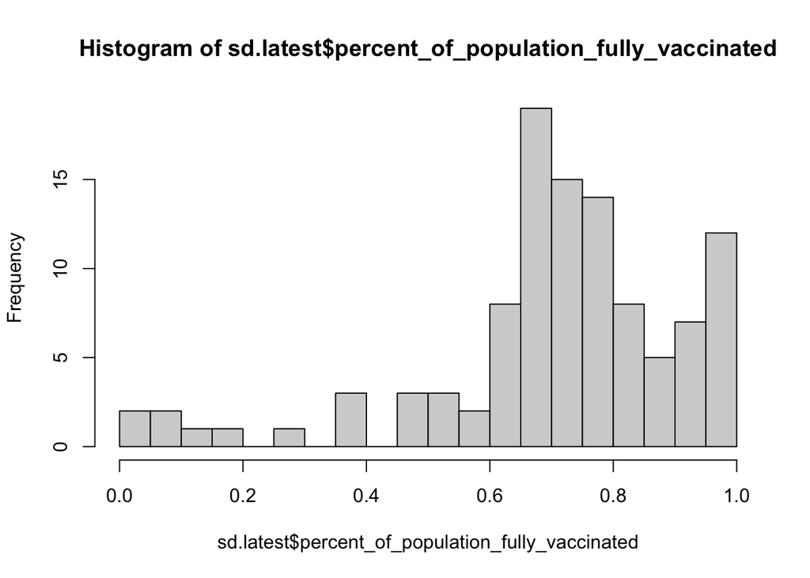

```r
hist(sd.latest$percent_of_population_fully_vaccinated, breaks = 30)
```

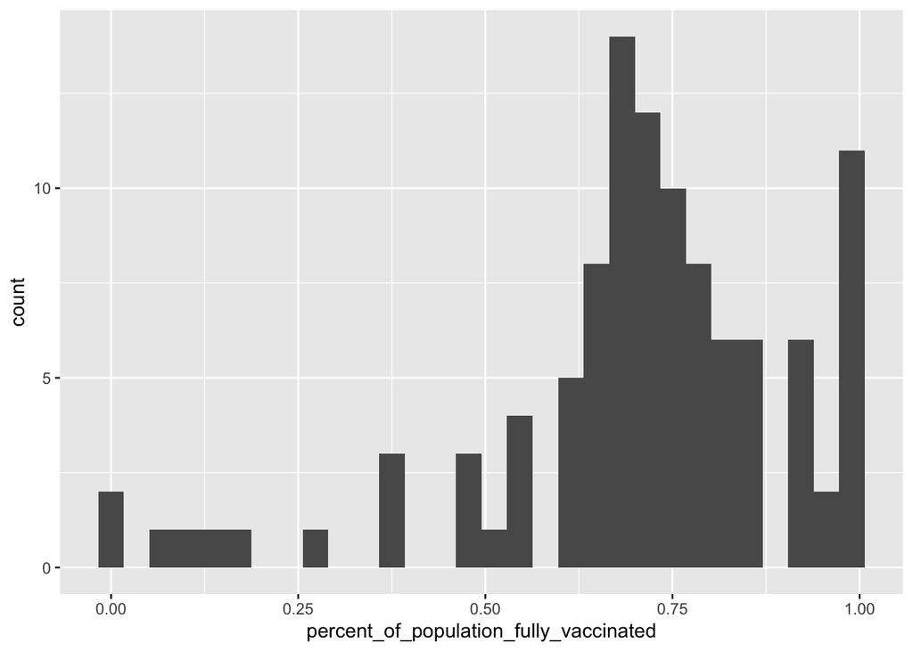

```r
library(ggplot2)

ggplot(sd.latest) +
  aes(percent_of_population_fully_vaccinated) + geom_histogram()
```

```r
ucsd <- filter(sd, zip_code_tabulation_area=="92037")
ucsd[1,]$age5_plus_population
```

```
## [1] 36144
```

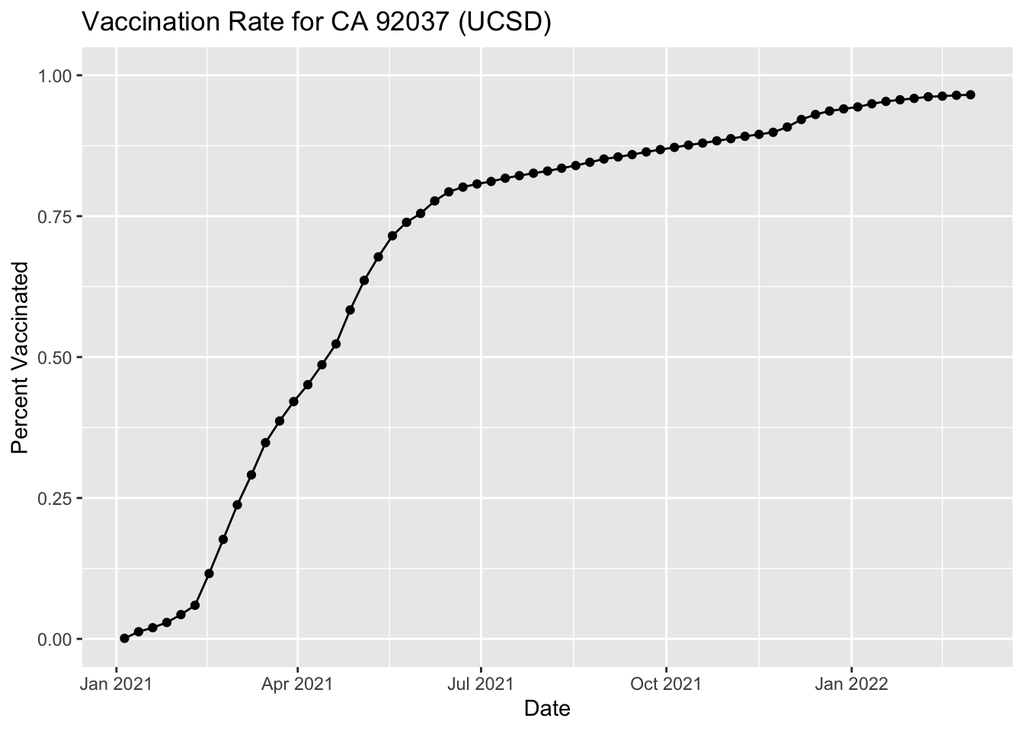

```r
baseplot = ggplot(ucsd) +
  aes(as_of_date, percent_of_population_fully_vaccinated) +
  geom_point() +
  geom_line(group=1) +
  ylim(c(0,1)) +
  labs(x ="Date", y="Percent Vaccinated") +
  labs(title="Vaccination Rate for CA 92037 (UCSD)")
baseplot
```

# Q16. Calculate the mean “Percent of Population Fully Vaccinated” for ZIP code areas with a population as large as 92037 (La Jolla) as_of_date “2022-02-22”. Add this as a straight horizontal line to your plot from above with the geom_hline() function?

```r
# Subset to all CA areas with a population as large as 92037
vax.36 <- filter(vax, age5_plus_population > 36144 &
                as_of_date == "2022-03-01")

#head(vax.36)
```

```r
mean.36 = mean(vax.36$percent_of_population_fully_vaccinated, na.rm=T)
mean.36
```

```
## [1] 0.7353974
```

Adding the lin3 showing the average vaccination rate for all zip code areas with a population just as large as 92037

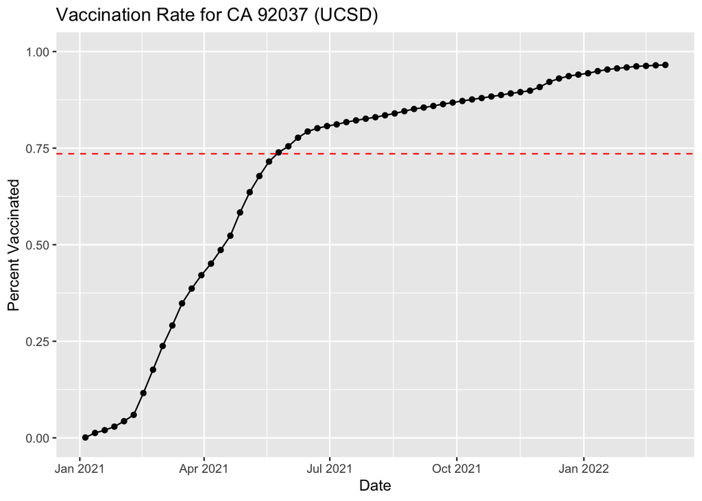

```r
baseplot + geom_hline(yintercept = mean.36, linetype=2, color = "red")
```

# Q17. What is the 6 number summary (Min, 1st Qu., Median, Mean, 3rd Qu., and Max) of the “Percent of Population Fully Vaccinated” values for ZIP code areas with a population as large as 92037 (La Jolla) as_of_date “2022-02-22”?

```r
summary(vax.36$percent_of_population_fully_vaccinated)
```

```
##    Min. 1st Qu.  Median    Mean 3rd Qu.    Max.
##  0.3890  0.6554  0.7350  0.7354  0.8044  1.0000
```

# Q18. Using ggplot generate a histogram of this data.

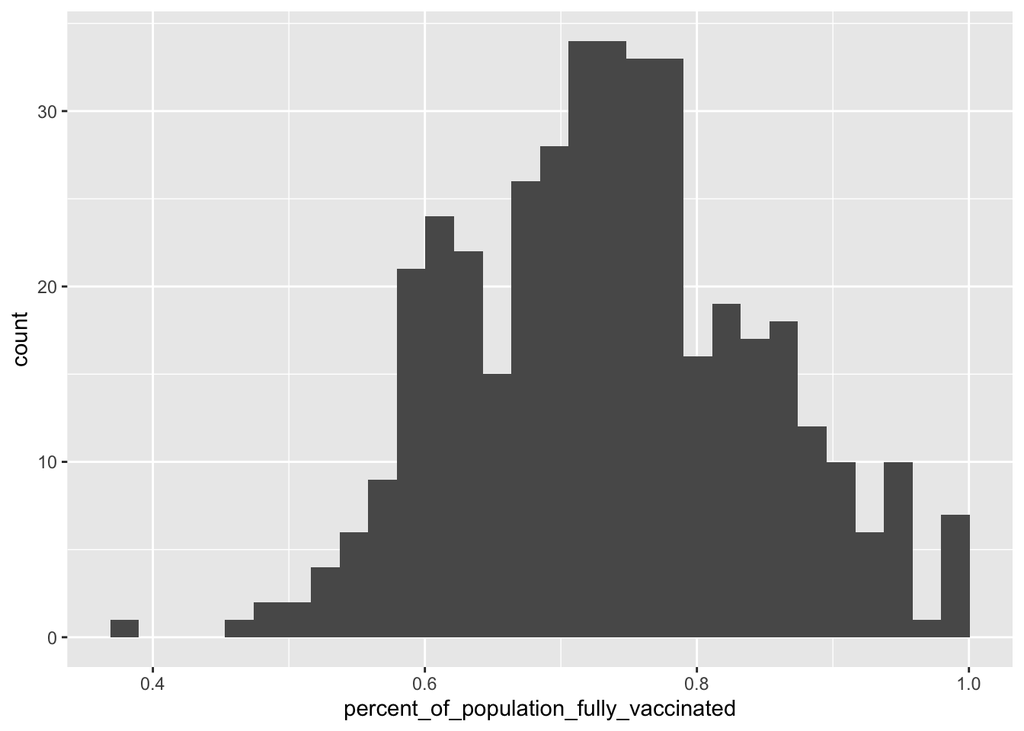

```r
ggplot(vax.36) +
  aes(percent_of_population_fully_vaccinated) + geom_histogram()
```

# Q19. Is the 92109 and 92040 ZIP code areas above or below the average value you calculated for all these above?

```r
vax %>% filter(as_of_date == "2022-03-01") %>%
  filter(zip_code_tabulation_area=="92040") %>%
  select(percent_of_population_fully_vaccinated)
```

| percent_of_population_fully_vaccinated |
| --- |
| 0.551981 |

#Q20. Finally make a time course plot of vaccination progress for all areas in the full dataset with a age5_plus_population > 36144.

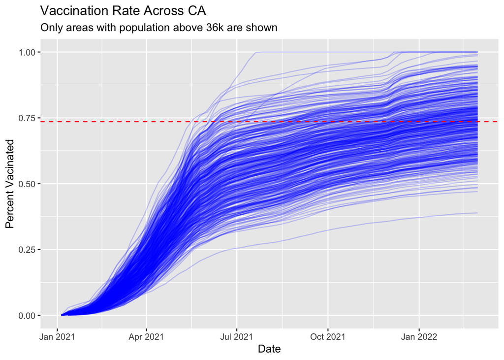

```r
vax.36.all <- filter(vax, age5_plus_population > 36144)


ggplot(vax.36.all) +
  aes(as_of_date,
      percent_of_population_fully_vaccinated,
      group=zip_code_tabulation_area) +
  geom_line(alpha=0.2, color="blue") +
  ylim(c(0,1)) +
  labs(x="Date", y="Percent Vacinated",
       title="Vaccination Rate Across CA",
       subtitle="Only areas with population above 36k are shown") +
  geom_hline(yintercept = mean.36, linetype=2, color = "red")
```

# Q21. How do you feel about traveling for Spring Break and meeting for in-person class afterwards?

Since on average area with 36k+ population have a percent vaccinated rate around 75, I feel safe traveling for Spring Break and meeting for in-person class afterward as long as we still keep the precautions for preventing COVID-19.